# Formal Analysis of the Hip Hop Dataset

- Show All Code
- Hide All Code
- View Source

Author

Frank Pham

[figure not shown]

Project C

## BSLIB Adjustments

```css
body {
  font-family: 'Roboto', sans-serif;
  background-color: #343a40;
  color: #ffffff;
}

h1, h2, h3, h4, h5, h6 {
  color: #ffffff;
}

.container {
  background-color: #212529;
  padding: 20px;
}

/* Change the appearance of code blocks */
pre, code {
  background-color: #f1f1f1;
  color: #004080;
}

a {
  color: #007bff;
}

.quarto-author {
  font-size: 1.2em;
}

#quarto-toc {
  font-size: 3em;
}
```

## Introduction

This data set `hiphop` contains data from a study conducted by a linguist at the University of Minnesota. The focus of this study was predicting musical taste based on `familiarity` with African American English (AAE). The study included 168 subjects particpated in this study, each asked to define 64 different AAE terms. Given those definitions, it was used to create a familiarity score for each subject for each term. The score is scored on a scale of 1-5 (1 = not at all, 5 = very well) quantifying, how well the subject knows the term.

## Load Data

```r
# Load necessary libraries
library(dplyr)
library(tidyverse)
library(here)
library(readr)
library(ggplot2)  # Add any other necessary libraries
library(bslib)

# Load the hiphop.csv dataset
hiphop_data <- readr::read_csv("hiphop.csv")
```

## Summary Statistics

```r
# clean the data and summarize it

hiphop_clean <- hiphop_data |>
  mutate(sex = as.factor(sex),
         word = as.factor(word),
         ethnic = as.factor(ethnic),
         subj = as.factor(subj),
         across(.cols = jayz:bieber, .fns = as.factor))
summary(hiphop_clean)
```

```
            word           subj           sex            age
 [to be] ghost: 168   p1     :   64   Female:7488   Min.   :16.00
 5-0          : 168   p10    :   64   Male  :3264   1st Qu.:18.00
 A-town       : 168   p101   :   64                 Median :19.00
 ashy         : 168   p102   :   64                 Mean   :20.02
 ay yo trip   : 168   p103   :   64                 3rd Qu.:20.00
 ballin'      : 168   p105   :   64                 Max.   :48.00
 (Other)      :9744   (Other):10368
      ethnic          city             county             intl
 white   :8640   Min.   :      0   Min.   :      0   Min.   : 0.0000
 asian   :1216   1st Qu.:  12807   1st Qu.:  99905   1st Qu.: 0.0000
 african : 320   Median :  42322   Median : 331582   Median : 0.0000
 hispanic: 192   Mean   : 159130   Mean   : 509216   Mean   : 0.3869
 indian  : 128   3rd Qu.: 103486   3rd Qu.: 959521   3rd Qu.: 0.0000
 biracial:  64   Max.   :8391881   Max.   :3053793   Max.   :15.0000
 (Other) : 192
     vocal          classical            folk             rock
 Min.   : 0.000   Min.   : 0.0000   Min.   :0.0000   Min.   : 0.000
 1st Qu.: 0.000   1st Qu.: 0.0000   1st Qu.:0.0000   1st Qu.: 0.000
 Median : 0.000   Median : 0.0000   Median :0.0000   Median : 1.000
 Mean   : 1.089   Mean   : 0.8095   Mean   :0.3988   Mean   : 2.274
 3rd Qu.: 1.000   3rd Qu.: 0.0000   3rd Qu.:0.0000   3rd Qu.: 4.000
 Max.   :11.000   Max.   :10.0000   Max.   :6.0000   Max.   :18.000

    country            pop          alternative         hiphop
 Min.   :0.0000   Min.   : 0.000   Min.   : 0.000   Min.   : 0.000
 1st Qu.:0.0000   1st Qu.: 0.000   1st Qu.: 0.000   1st Qu.: 0.000
 Median :0.0000   Median : 1.000   Median : 2.000   Median : 0.000
 Mean   :0.6667   Mean   : 1.238   Mean   : 2.196   Mean   : 1.595
 3rd Qu.:0.0000   3rd Qu.: 2.000   3rd Qu.: 4.000   3rd Qu.: 3.000
 Max.   :7.0000   Max.   :11.000   Max.   :13.000   Max.   :10.000

 unclassifiable     countyBlack     jayz     barkley  boondocks monique
 Min.   :0.00000   Min.   :     0   1:2880   1:7104   1:8768    1:4416
 1st Qu.:0.00000   1st Qu.:   675   2: 192   2: 704   2:  64    2:1088
 Median :0.00000   Median :  7748   3: 128   3:1920   3: 128    3:3136
 Mean   :0.05357   Mean   : 46404   4: 128   5:1024   4:  64    4:1728
 3rd Qu.:0.00000   3rd Qu.: 50842   5:7424            5:1728    5: 384
 Max.   :1.00000   Max.   :942470

```

[output cut: 17 more lines]

```
 Min.   :0.0000   Min.   :0.0000   Min.   :1.000   Min.   : 1.00
 1st Qu.:0.0000   1st Qu.:0.0000   1st Qu.:1.000   1st Qu.:16.75
 Median :1.0000   Median :0.0000   Median :1.000   Median :32.50
 Mean   :0.7321   Mean   :0.1845   Mean   :1.818   Mean   :32.50
 3rd Qu.:1.0000   3rd Qu.:0.0000   3rd Qu.:1.000   3rd Qu.:48.25
 Max.   :1.0000   Max.   :1.0000   Max.   :5.000   Max.   :64.00

      fam1      popularityScore  numPreferredArtists numOverallArtists
 Min.   :0.00   Min.   :  0.00   Min.   :0.000       Min.   : 0.000
 1st Qu.:0.00   1st Qu.:  0.00   1st Qu.:0.000       1st Qu.: 0.000
 Median :0.00   Median : 21.00   Median :0.000       Median : 3.000
 Mean   :0.24   Mean   : 27.64   Mean   :0.338       Mean   : 5.953
 3rd Qu.:0.00   3rd Qu.: 42.50   3rd Qu.:0.000       3rd Qu.: 8.000
 Max.   :1.00   Max.   :120.00   Max.   :6.000       Max.   :28.000
                                 NA's   :5632        NA's   :5632
```

## Data Visualization

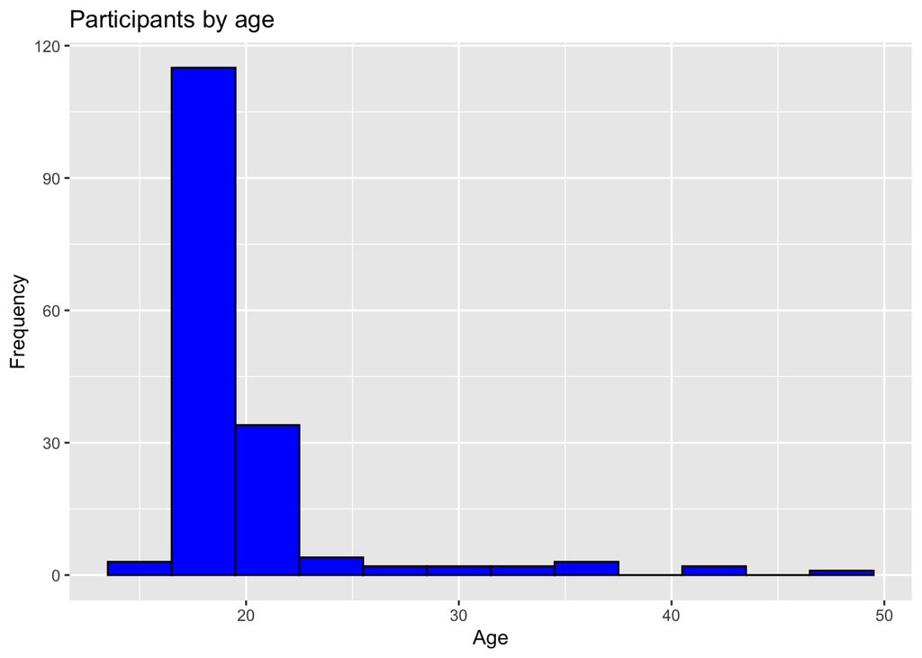

```r
hiphop_clean1 <- hiphop_clean |>
  distinct(subj, .keep_all = TRUE)|>
  select(sex:ethnic)

hiphop_age <- hiphop_clean1 |>
  count(age)

hiphop_ethnic <- hiphop_clean1 |>
  count(ethnic)

hiphop_sex <- hiphop_clean1 |>
  count(sex)
ggplot(data = hiphop_clean1, mapping = aes(x = age)) +
  geom_histogram(binwidth = 3, color = "black", fill = "blue") +
  labs(x = "Age",
       y = "Frequency",
       title = "Participants by age")
```

In this dataset, we notice that there is a clear right skewed distribution of participants by age. There seems to be a particular spike right before the age of 20. Becasue the bid width is 3, it safe to suggest that each bar in the graph is represented by the range of three years.

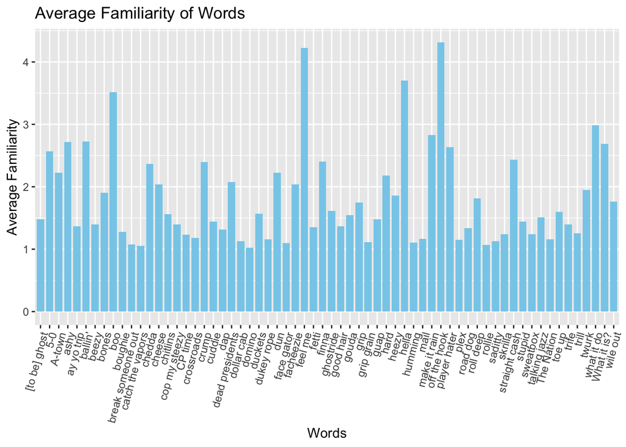

```r
# Calculate the average familiarity for each word
average_familiarity <- hiphop_data %>%
  group_by(word) %>%
  summarize(avg_familiarity = mean(familiarity))

# Create a bar plot
ggplot(average_familiarity, aes(x = word, y = avg_familiarity)) +
  geom_bar(stat = "identity", fill = "skyblue", width = 0.8, position = position_dodge(width = 10)) +
  labs(title = "Average Familiarity of Words",
       x = "Words",
       y = "Average Familiarity") +
  theme(axis.text.x = element_text(angle = 75, hjust = 1))
```

This bar plot depict the average familiarity scores displays a diverse range of familiarity scores. This would highlight differences in the participants knowledge of specific words. Words with a higher bar meant that the average familiarity was higher. Some phrases that were particularly high was “feel me” and “off the hook”.

## Statistical Analysis

```r
hiphop_clean <- na.omit(hiphop_data)
t_test_result <- t.test(hiphop_clean$familiarity, mu = 0)
t_test_result
```

```
    One Sample t-test

data:  hiphop_clean$familiarity
t = 86.713, df = 5119, p-value < 2.2e-16
alternative hypothesis: true mean is not equal to 0
95 percent confidence interval:
 1.918131 2.006869
sample estimates:
mean of x
   1.9625
```

Becasue the p value is below 0.05, we have sufficent evidence that the mean familiarity score is unlikely to have happened by chance. The low p-value also gives us sufficient evidence to reject the null hypothesis. The positive sample mean however suggests that the participants in the given study had a positive familiarity with the vocabulary terms that they were tested on.

## Regression Analysis

```r
model <- lm(familiarity ~ age + ethnic + sex + hiphop + bieber, data = hiphop_data)

# View model summary
summary(model)
```

```
Call:
lm(formula = familiarity ~ age + ethnic + sex + hiphop + bieber,
    data = hiphop_data)

Residuals:
    Min      1Q  Median      3Q     Max
-2.2344 -0.8336 -0.6629 -0.3644  3.6769

Coefficients:
                 Estimate Std. Error t value Pr(>|t|)
(Intercept)     1.8594921  0.1154971  16.100  < 2e-16 ***
age            -0.0001288  0.0032484  -0.040 0.968384
ethnicasian    -0.2765741  0.0956084  -2.893 0.003826 **
ethnicbiracial  0.3804697  0.2073338   1.835 0.066525 .
ethnicblack     1.3373859  0.2103058   6.359 2.11e-10 ***
ethnichispanic -0.3593609  0.1415105  -2.539 0.011116 *
ethnicindian   -0.5750133  0.1592071  -3.612 0.000306 ***
ethnicnative   -0.2579361  0.2079068  -1.241 0.214768
ethnicunknown  -0.1080201  0.2095338  -0.516 0.606196
ethnicwhite    -0.2607152  0.0874203  -2.982 0.002867 **
sexMale         0.1518850  0.0336683   4.511 6.51e-06 ***
hiphop          0.0706478  0.0070649  10.000  < 2e-16 ***
bieber          0.0205510  0.0119702   1.717 0.086036 .
---
Signif. codes:  0 '***' 0.001 '**' 0.01 '*' 0.05 '.' 0.1 ' ' 1

Residual standard error: 1.51 on 10739 degrees of freedom
Multiple R-squared:  0.02253,   Adjusted R-squared:  0.02144
F-statistic: 20.63 on 12 and 10739 DF,  p-value: < 2.2e-16
```

A few key issues to notice here is that we notice that the expected mean familiarity is 1.859 when `age`, `hiphop`, and `bieber` and other variables were all 0. We also see that there are certain significant predictors of familiarity which included `ethnicasian`, `ethnicblack`, `ethnichispanic`, `ethnicindian`, `ethnicwhite`, `sexMale`, and `hiphop`.

## Conclusion

After this statistical analysis, I have uncovered that the linear regression model is statistically significant which means that at least one predictor variable is significant when predicing the familiarity with hip hop. While we see the significant predictors in the `Regression Analysis`, it is shown that `age` and `bieber` are not significant since their p-value is greater than 0.05. Also shown in the results of this analysis is that the variable`hiphop` has a strong association with hip hop music which is connected to higher familiarity scores. In conlusion, the results of this study reveals the significant associations between ethnicity, music preferences and the familiarity with hip-hop vocabulary.